# TP_Estadistica

2024-10-13

# Trabajo Práctico Estadística

## Alumnos:

Bertea Anguinetti, Francisco José (45085317) Miotti, Camilo (45409165) Roncoroni, Juan Ignacio (44943486) Sposetti, Estrella Lucia (44974744)

Luego de 10 meses asumido en el cargo de presidente Javier Milei, y tras realizar una encuesta a más de 900 personas en la Provincia de Córdoba, hemos decidido realizar un estudio acerca de la plataforma discursiva presentada por Milei en campaña electoral. En la misma, se pudo identificar tres ejes centrales de preocupación a partir de las cuales giraron sus propuestas: la inflación, el déficit fiscal y la corrupción. Si bien el discurso del ahora presidente ha tenido variantes a lo largo del tiempo, se tratan de tres dimensiones que englobaron claramente la impronta comunicacional de su campaña. En ese sentido, este estudio buscó profundizar la percepción de dichos problemas entre los votantes de Milei. A través de la encuesta realizada, se pudo acceder a datos muestrales que nos permitieron ahondar sobre la importancia de las dimensiones antes planteadas -entre otras-.

Primero subimos la Base de Datos

```r
library(readxl)
datos = read.csv("E:/FCS-UNC/Liceniatura en Ciencia Política/6to Cuatrimestre/TeDeCi/Encuesta Estadística II 2024 (respuestas) - Respuestas de formulario 1 (1).csv")
```

Luego de ello hacemos un filtro sobre los votantes de Javier Milei en las elecciones generales

```r
library(tidyverse)
voto_milei_g = filter(datos, datos$generales == "Javier Milei")
nrow (voto_milei_g)
```

```
## [1] 253
```

Sobre ese mismo filtro calculamos los intervalos de confianza de la proporción votantes que identificaron como prioridades urgentes que deben ser resueltas por el Gobierno Nacional a:

### 1. Inflación

Primero calculamos objetos visuales (data frame), el primero hace referencia a los “fracasos”, mientras que el segundo hace referencia a nuestra categoria “éxito”, en este caso “Inflación”

```r
library(gmodels)

df_interes <- voto_milei_g %>%
  select(orden_corrupcion, orden_deficit, orden_inseguridad, orden_pobreza, orden_desempleo, orden_desigualdad, orden_educacion)

df_interes_limpio <- df_interes[!is.na(df_interes) & df_interes != ""]

frecuencias <- table(unlist(df_interes_limpio))

frecuencias_orden <- data.frame(Var1 = names(frecuencias), Freq = as.vector(frecuencias))

print (frecuencias_orden)
```

```
##   Var1 Freq
## 1   1°  152
## 2   2°  220
## 3   3°  211
```

```r
df_interes_inflacion <- voto_milei_g %>%
  select(orden_inflacion)

df_interes_limpio_inflacion <- df_interes_inflacion[!is.na(df_interes_inflacion) & df_interes_inflacion != ""]

frecuencias_inflacion <- table(unlist(df_interes_limpio_inflacion))

frecuencias_orden_inflacion <- data.frame(Var1 = names(frecuencias_inflacion), Freq = as.vector(frecuencias_inflacion))

print (frecuencias_orden_inflacion)
```

```
##   Var1 Freq
## 1   1°  101
## 2   2°   33
## 3   3°   41
```

Luego calculamos la distribucion de frecuencias de cada data frame

```r
suma_orden_otros = sum(frecuencias_orden$Freq)

suma_orden_inflacion = sum(frecuencias_orden_inflacion$Freq)

suma_orden_todo = suma_orden_otros + suma_orden_inflacion
```

Calculamos la proporción de “éxitos” para poder hacer los cálculos correspondientes a los intervalos de confianza

```r
prop_inflacion = suma_orden_inflacion / (suma_orden_otros + suma_orden_inflacion)

print(prop_inflacion)
```

```
## [1] 0.2308707
```

Calculamos el *error de estimación*…

```r
error_estimacion <- 1.96 * sqrt((prop_inflacion * (1 - prop_inflacion)) / suma_orden_todo)

print (error_estimacion)
```

```
## [1] 0.02999892
```

Y por último establecemos los *límites del intervalo*

```r
limite_inf_inflacion = prop_inflacion-error_estimacion

print(limite_inf_inflacion)
```

```
## [1] 0.2008718
```

```r
limite_sup_inflacion = prop_inflacion+error_estimacion

print(limite_sup_inflacion)
```

```
## [1] 0.2608696
```

El intervalo de confianza calculado es: (0.20 ; 0.26)

### 2. Corrupción

Primero calculamos objetos visuales (data frame), el primero hace referencia a los “fracasos”, mientras que el segundo hace referencia a nuestra categoria “éxito”, en este caso “Corrupción”

```r
df_interes_no_corr <- voto_milei_g %>%
  select(orden_inflacion, orden_deficit, orden_inseguridad, orden_pobreza, orden_desempleo, orden_desigualdad, orden_educacion)

df_interes_limpio_no_corr <- df_interes_no_corr[!is.na(df_interes_no_corr) & df_interes_no_corr != ""]

frecuencias_no_corr <- table(unlist(df_interes_limpio_no_corr))

frecuencias_orden_no_corr <- data.frame(Var1 = names(frecuencias_no_corr), Freq = as.vector(frecuencias_no_corr))

print (frecuencias_orden_no_corr)
```

```
##   Var1 Freq
## 1   1°  237
## 2   2°  222
## 3   3°  225
```

```r
df_interes_corr <- voto_milei_g %>%
  select(orden_corrupcion)

df_interes_limpio_corr <- df_interes_corr[!is.na(df_interes_corr) & df_interes_corr != ""]

frecuencias_corr <- table(unlist(df_interes_limpio_corr))

frecuencias_orden_corr <- data.frame(Var1 = names(frecuencias_corr), Freq = as.vector(frecuencias_corr))

print (frecuencias_orden_corr)
```

```
##   Var1 Freq
## 1   1°   16
## 2   2°   31
## 3   3°   27
```

Luego calculamos la distribución de frecuencias de cada data frame

```r
suma_orden_no_corr = sum(frecuencias_orden_no_corr$Freq)

suma_orden_corr = sum(frecuencias_orden_corr$Freq)
```

Calculamos la proporción de “éxitos” para poder hacer los cálculos correspondientes a los intervalos de confianza

```r
prop_corr = suma_orden_corr / suma_orden_todo

print (prop_corr)
```

```
## [1] 0.09762533
```

Calculamos el *error de estimación*…

```r
error_estimacion_corr <- 1.96 * sqrt((prop_corr * (1 - prop_corr)) / suma_orden_todo)

print (error_estimacion_corr)
```

```
## [1] 0.02112984
```

Y por último establecemos los *límites del intervalo*

```r
limite_inf_corr = prop_corr-error_estimacion_corr

print(limite_inf_corr)
```

```
## [1] 0.07649549
```

```r
limite_sup_corr = prop_corr+error_estimacion_corr

print(limite_sup_corr)
```

```
## [1] 0.1187552
```

El intervalo de confianza calculado es: (0.07 ; 0.12)

### 3. Déficit Fiscal

Primero calculamos objetos visuales (data frame), el primero hace referencia a los “fracasos”, mientras que el segundo hace referencia a nuestra categoria “éxito”, en este caso “Deficit Fiscal”

```r
df_interes_no_df <- voto_milei_g %>%
  select(orden_inflacion, orden_corrupcion, orden_inseguridad, orden_pobreza, orden_desempleo, orden_desigualdad, orden_educacion)

df_interes_limpio_no_df <- df_interes_no_df[!is.na(df_interes_no_df) & df_interes_no_df != ""]

frecuencias_no_df <- table(unlist(df_interes_limpio_no_df))

frecuencias_orden_no_df <- data.frame(Var1 = names(frecuencias_no_df), Freq = as.vector(frecuencias_no_df))

print(frecuencias_orden_no_df)
```

```
##   Var1 Freq
## 1   1°  239
## 2   2°  239
## 3   3°  228
```

```r
df_interes_df <- voto_milei_g %>%
  select(orden_deficit)

df_interes_limpio_df <- df_interes_df[!is.na(df_interes_df) & df_interes_df != ""]

frecuencias_df <- table(unlist(df_interes_limpio_df))

frecuencias_orden_df <- data.frame(Var1 = names(frecuencias_df), Freq = as.vector(frecuencias_df))

print(frecuencias_orden_df)
```

```
##   Var1 Freq
## 1   1°   14
## 2   2°   14
## 3   3°   24
```

Luego calculamos la distribución de frecuencias de cada data frame

```r
suma_orden_no_df = sum(frecuencias_orden_no_df$Freq)

suma_orden_df = sum(frecuencias_orden_df$Freq)
```

Calculamos la proporción de “éxitos” para poder hacer los cálculos correspondientes a los intervalos de confianza

```r
prop_df = suma_orden_df / suma_orden_todo

print (prop_df)
```

```
## [1] 0.06860158
```

Calculamos el *error de estimación*…

```r
error_estimacion_df <- 1.96 * sqrt((prop_df * (1 - prop_df)) / suma_orden_todo)

print(error_estimacion_df)
```

```
## [1] 0.01799518
```

Y por último establecemos los *límites del intervalo*

```r
limite_inf_df = prop_corr-error_estimacion_df

print(limite_inf_df)
```

```
## [1] 0.07963015
```

```r
limite_sup_df = prop_corr+error_estimacion_df

print(limite_sup_df)
```

```
## [1] 0.1156205
```

Retomando la pregunta acerca de la construcción discursivo-ideológica sobre las urgencias del país hecha por Javier Milei, obtuvimos resultados interesantes. A pesar de haber una distribución dispersa entre las variables a elegir -siendo 8 en total y luego tuvieron que jerarquizarse en 3- la inflación fue la que primó entre las 3 que consideramos relevantes para nuestro análisis. Tal vez, una salvedad metodológica podría ser no proponer tantas categorías en un próximo estudio, ya que no es posible identificar cuestiones determinantes en base a ello. Sin embargo, es posible esbozar una hipótesis acerca del problema de la inflación como algo que preocupa a una gran cantidad de votantes de la Libertad Avanza en mayor medida que la corrupción y el déficit fiscal. Es preciso, entonces, observar el comportamiento de dichas variables en términos generales para poder incluir al total de dichos votantes:

```r
library(gmodels)

#Inflación
ci(voto_milei_g$problemas_inflacion)
```

```
##   Estimate   CI lower   CI upper Std. Error
##  8.2490119  7.9696002  8.5284235  0.1418749
```

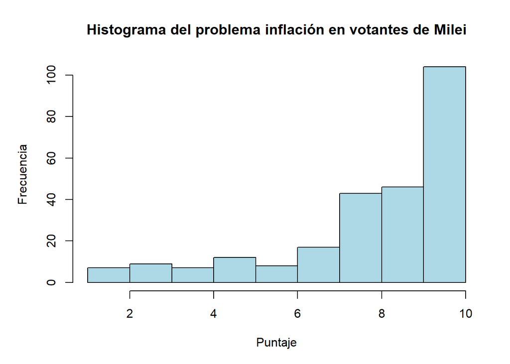

```r
par(mar=c(5, 5, 4, 2))
hist(voto_milei_g$problemas_inflacion, main = "Histograma del problema inflación en votantes de Milei", ylab =  "Frecuencia", xlab = "Puntaje", col = "lightblue")
```

```r
#Corrupción
ci(voto_milei_g$problemas_corrupcion)
```

```
##   Estimate   CI lower   CI upper Std. Error
##  8.3557312  8.0801924  8.6312701  0.1399085
```

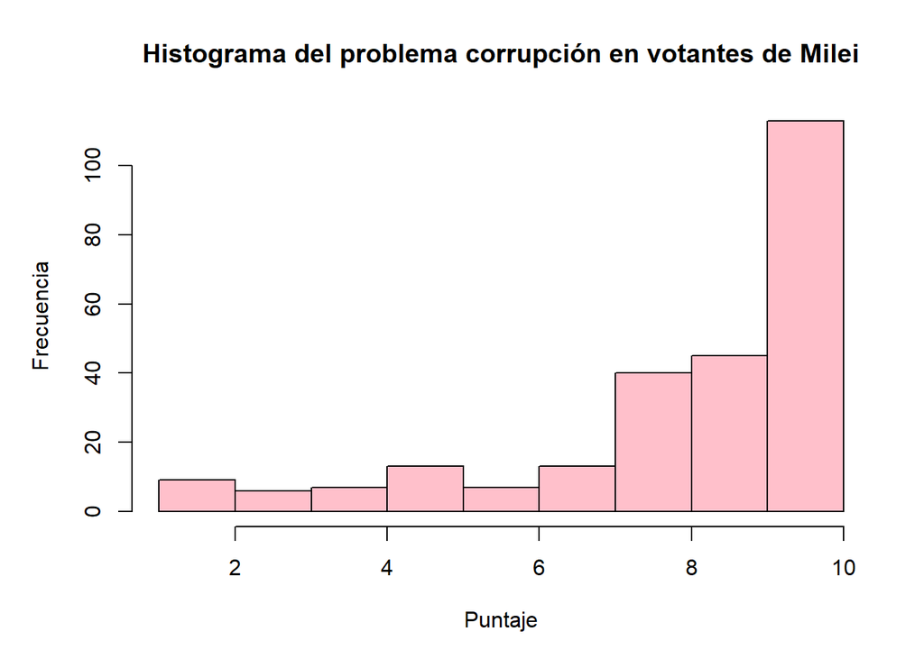

```r
par(mar=c(5, 5, 4, 2))
hist(voto_milei_g$problemas_corrupcion, main = "Histograma del problema corrupción en votantes de Milei", ylab =  "Frecuencia", xlab = "Puntaje", col = "pink")
```

```r
#Deficit
ci(voto_milei_g$problemas_deficit)
```

```
##   Estimate   CI lower   CI upper Std. Error
##  7.3517787  7.0550111  7.6485462  0.1506876
```

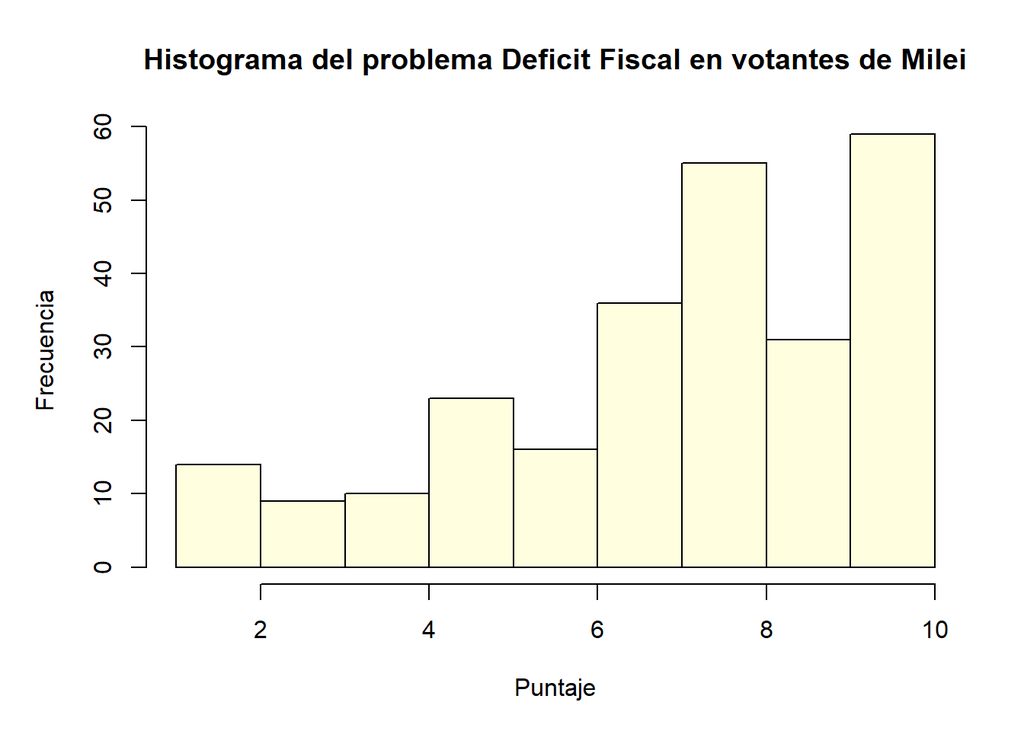

```r
par(mar=c(5, 5, 4, 2))
hist(voto_milei_g$problemas_deficit, main = "Histograma del problema Deficit Fiscal en votantes de Milei", ylab =  "Frecuencia", xlab = "Puntaje", col = "lightyellow")
```

Como se observa, es posible estimar con un 95% de confianza que la media poblacional sobre aquellas personas que votaron en primera vuelta a Javier Milei comprenden a la inflación y a la corrupción -cuyos intervalos de confianza se superponene, como podemos observar: Inlfación (7.96 ; 8.52) y Corrupción (8.08 ; 8.63)- como varibales más problematicas que el deficit fiscal, cuyo intervalo de confianza se encuentra por debajo de ellos dos y está comprendido entre (7.05 ; 7.64).

En este sentido, y para dar una conclusión final al análisis en cuestión, podemos decir que por más de que los votantes más “duros” de Javier Milei (quienes lo votaron en primera vuelta) consideren temas de mayor problematicidad la inflación y la corrupción, esto no se corresponde directamente con la relevancia que estas variables adquieren a la hora de ser tratados con “urgencia” por parte del Gobierno Nacional, siendo solo la inflación la variable más elegida por aquellos votantes, con sus intervalos de confianza ya elaborados en los apartados superiores.